# Untitled

2022-06-23 10:00:00

## 복습

-iris 데이터, sepal.length, sepal. width활용해서 종별로 산점도를 그리세요 -제목과 x축 y축 제목을 변경하세요. +x축 길이 , y축 너비

```r
library(ggplot2)
str(iris)
```

```
## 'data.frame':    150 obs. of  5 variables:
##  $ Sepal.Length: num  5.1 4.9 4.7 4.6 5 5.4 4.6 5 4.4 4.9 ...
##  $ Sepal.Width : num  3.5 3 3.2 3.1 3.6 3.9 3.4 3.4 2.9 3.1 ...
##  $ Petal.Length: num  1.4 1.4 1.3 1.5 1.4 1.7 1.4 1.5 1.4 1.5 ...
##  $ Petal.Width : num  0.2 0.2 0.2 0.2 0.2 0.4 0.3 0.2 0.2 0.1 ...
##  $ Species     : Factor w/ 3 levels "setosa","versicolor",..: 1 1 1 1 1 1 1 1 1 1 ...
```

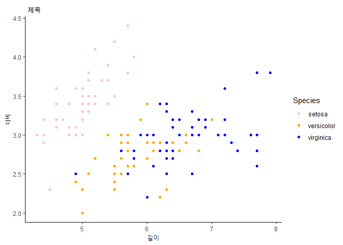

```r
ggplot(iris, aes( x = Sepal.Length,
                  y = Sepal.Width,
                  colour =Species))+
  geom_point()+
   labs(
     title =" 제목",
         x = "길이",
         y = "너비",
   )+
  scale_color_manual(
    labels = c("setosa","versicolor","virginica"),
    values = c("pink","orange","blue")
  )+
  theme_classic()
```

– 색깔을 부꿀 수 있는 명령어 scale_color_manual – 테마를 바꾸는 옵션 theme_classic()-> 농도가 각각 다르게 함. – ggstatsplot라는 것도 통계그림 그리기에 좋음

## 통계

- 기술통계 :평균, 최촛값, 최댓값, 중간값
- 추론통계 : 변수간의 관계를 파악/새로운 사실을 발견(추정) +평균차이 검정 -수치데이터 -가설검정 : 평균의 차이를 검정 -남자의 평균 키와 여자의 평균 키는 차이가 있을 것이다. (남자 여자라는 그룹을 평균을 기준으로 비교 )

  +교차분석(빈도분석)  
  -범주 데이터 -가설검정 : 각 범주별 빈도를 활용하여 관계성을 검정

  +상관관계 분석 -수치 데이터 -변수사이의 연관성을 수치로 표현

  +단순 회귀분석 -y(종속변수)= a(기울기=회기계수)x(독립변수)+b(절편=상수항:의미없음) -가설검정 ->기온x(독립변수)이 판매량y(종속변수)에 긍정적(+)a영향을 준다.

  +다중 회귀분석 -y=a1x1+a2x2+a3x3….+b

## 통계 검정

- P176

### 가설

-hypothesis –>공부방법: 선행연구, 해당분석방법의 가설 설정 예시를 보고 연습 -연구:내가 궁금한 것을 찾는 것 ex)남자와 여자의 평균키가 차이가 있다. -귀무가설:궁금한 것의 반대내용(ex.남여 평균키 차이가 없다.) -대립가설:궁금한 사항이 여기로 옴(ex.남여 평균키 차이가 있다)

-가설 검정에서 인정하는 유의 수준:5%,1%,0.1% 또는 10% -오차 범위 내에 있으면 차이가 크지 않음. 오차 범위 밖에 있으면 결과가 결정됨.(신뢰수준<->유의수준) -유의수준>0.05가 넘으면 데이터의 의미가 없어진다.귀무가설 실패

t.test -어떻게 데이터를 입력하는지 확인 -p-value, 유의수준 0.05이상: 귀무가설(p>0.05) 0.05이내: 대립가설(p<0.05)

```r
mpg1<-read.csv("data/mpg1.csv",stringsAsFactors = F)
str(mpg1)
```

```
## 'data.frame':    234 obs. of  5 variables:
##  $ manufacturer: chr  "audi" "audi" "audi" "audi" ...
##  $ trans       : chr  "auto" "manual" "manual" "auto" ...
##  $ drv         : chr  "f" "f" "f" "f" ...
##  $ cty         : int  18 21 20 21 16 18 18 18 16 20 ...
##  $ hwy         : int  29 29 31 30 26 26 27 26 25 28 ...
```

-시각화 +여기서는 큰 차이를 알 수가 없다.

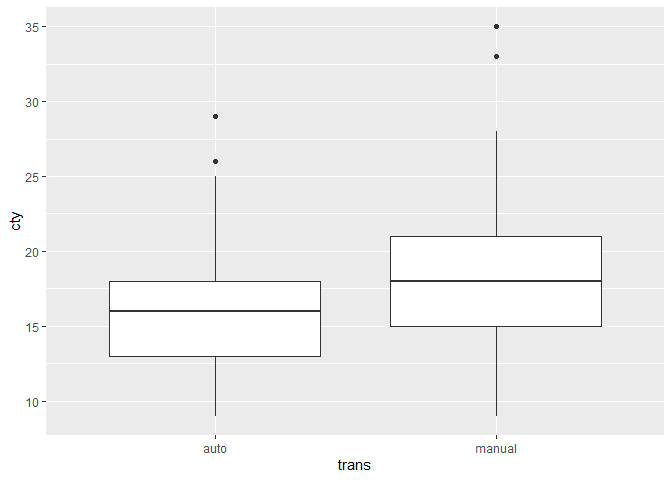

```r
library(ggplot2)
ggplot(mpg1, aes(x = trans, y = cty)) +
  geom_boxplot()
```

-t.test 검정 +귀무가설 :auto와 manual의 cty평균은 차이가 없다. +대립가설 :auto와 manual의 cty평균은 차이가 있다.

```r
t.test(data = mpg1, cty ~ trans)
```

```
##
##  Welch Two Sample t-test
##
## data:  cty by trans
## t = -4.5375, df = 132.32, p-value = 1.263e-05
## alternative hypothesis: true difference in means between group auto and group manual is not equal to 0
## 95 percent confidence interval:
##  -3.887311 -1.527033
## sample estimates:
##   mean in group auto mean in group manual
##             15.96815             18.67532
```

```r
                    #종속변수 ~ 독립변수 Y ~ X 반응변수 ~ 설명변수
```

–시각화한 것은 차이를 모르겠지만 통계를 통해 차이가 있음을 알 수 있다.(대립가설 성립)P-value<0.5

-cf..두 그룹의 평균 차이 검정하기 전에 +사전 필수 검증요소가 있다.바로 등분산 검정

+등분산 검정 ->두 그룹간의 분산이 비슷하면 –>t.test(모수검정) ->두 그룹간의 분산이 다르면–>(비모수검정) ->귀무가설: 두 그룹간의 분산이 비슷하다 p.value>0.05 ->대립가설: 두 그룹간의 분산이 다르다.

```r
var.test(data =mpg1, cty~trans)
```

```
##
##  F test to compare two variances
##
## data:  cty by trans
## F = 0.73539, num df = 156, denom df = 76, p-value = 0.1101
## alternative hypothesis: true ratio of variances is not equal to 1
## 95 percent confidence interval:
##  0.4912917 1.0719468
## sample estimates:
## ratio of variances
##          0.7353887
```

p.value>0.05이므로 귀무가설 성립. 등분산으로 본다.

-시각화

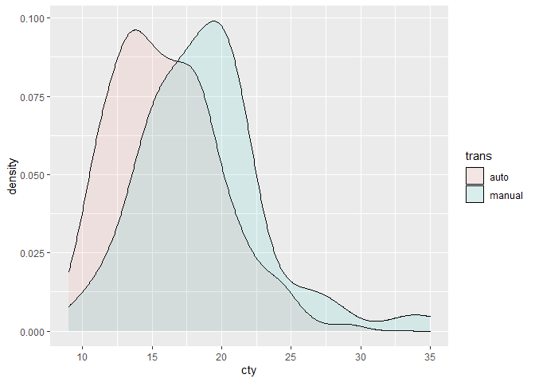

```r
ggplot(mpg1, aes(x = cty, fill = trans)) +
  # geom_histogram() +
  geom_density(alpha = 0.1)
```

### 교차 분석 -범주형 변수들이 관계가 있다는 것을 검정 -비율에 차이가 있는 지 검정 -교차분석 검정은 R의 chisq.test()함수로 진행 -귀무가설: tras에 따라 drv(4,f,r)의 (비율)차이가 없다. -대립가설: tras에 따라 drv의 차이가 있다. -빈도표/비율 -1빈도표

```r
table(mpg1$trans,mpg1$drv)#교차분석석
```

```
##
##           4  f  r
##   auto   75 65 17
##   manual 28 41  8
```

-2비율

```r
prop.table(table(mpg1$trans,mpg1$drv),1)
```

```
##
##                  4         f         r
##   auto   0.4777070 0.4140127 0.1082803
##   manual 0.3636364 0.5324675 0.1038961
```

-auto 4륜구동이 47% -manual 전륜구동이 53% 가장 많음 -실제로 통계적으로 봤을 때 차이가 있는지 검정

-귀무가설: tras에 따라 drv(4,f,r)의 (비율)차이가 없다. -대립가설: tras에 따라 drv의 차이가 있다.

```r
chisq.test(mpg1$trans,mpg1$drv)
```

```
##
##  Pearson's Chi-squared test
##
## data:  mpg1$trans and mpg1$drv
## X-squared = 3.1368, df = 2, p-value = 0.2084
```

p.value>0.05이므로 귀무가설 성립. 차이가 없다.